# WEB SCRAPING

## AGENDA

- Wprowadzenie do web scrapingu
- Przykładowe strony
  - ekstrakcja danych (css selector)
  - nawigowanie po stronach
  - JavaScript bez Selenium

## O mnie

- Od ponad 7 lat związany z firmą [HTA Consulting](http://www.hta.pl)
- Od roku własna działalność gospodarcza nastawiona na szeroko pojęte Data Science i automatyzację pracy
- Od 2014 roku główny organizator meetupu [eRka](https://www.meetup.com/pl-PL/erkakrakow/) w Krakowie
- Od 2018 roku członek zarządu fundacji [Why R?](http://whyr.pl/)

Kontakt: bartosz.pawel.sekiewicz@gmail.com

Blog/Portfolio: http://www.worksmarter.pl

## Wprowadzenie do web scrapingu

## Web crawler vs web scraping

- web crawler, czyli [robot internetowy](https://en.wikipedia.org/wiki/Web_crawler)
  - indeksowanie stron, zbieranie adresów, maili, numerów telefonów
  - wiele zapytań w krótkim czasie ([tysiące stron na minutę](http://digitalpebble.blogspot.com/2017/01/the-battle-of-crawlers-apache-nutch-vs.html))
  - opiera się na zdefiniowaniu reguł filtrowania adresów url
- web scraping, czyli [ekstrakcja danych ze stron www](https://en.wikipedia.org/wiki/Web_scraping)
  - ekstrakcja danych ze stron, które się często aktualizują
  - większy zakres obsługiwanych stron (formularze, js, serwisy)
  - analiza kodu źródłowego, każda strona jest traktowana indywidualnie

## Skrypty vs symulacja przeglądarki

- Skrypty:
  - szybkie działanie (+)
  - można uruchomić praktycznie w każdym środowisku (+)
  - problemy przy stronach obsługiwanych przez z JS, oraz stronach typu aspx, asmx, itd. (-)
- Symulacja klikania przez użytkownika:
  - szybkie w budowaniu (+)
  - idealne na jednorazowe pobranie danych (+)
  - wolne działanie (-)
  - nierzadko skrypty zawodzą (-)

## Narzędzia

- R
  - [RCurl](http://www.omegahat.net/RCurl/), [httr](https://cran.r-project.org/web/packages/httr/vignettes/quickstart.html)
  - [xml2](https://cran.r-project.org/web/packages/xml2/vignettes/modification.html), rvest
  - RSelenium
  - [RCrawler](https://github.com/salimk/Rcrawler/)
- Python
  - [urllibX](https://stackoverflow.com/questions/20467107/which-urllib-i-should-choose), [requests](https://pypi.org/project/requests/)
  - [beautifulsoup4](https://pypi.org/project/beautifulsoup4/)
  - [selenium](https://pypi.org/project/selenium/)
  - [scrapy](https://scrapy.org/)

## Narzędzia

- Java
  - [Nutch](http://nutch.apache.org/)
  - [StormCrawler](http://stormcrawler.net/)
- Praktycznie każdy język posiada bilioteki do web scrapingu
  - Perl
  - PHP
  - VBA (MSXML2.XMLHTTP, InternetExplorer.Application)
- Dedykowane narzędzia
  - [Octoparse](https://www.octoparse.com/)
  - i wiele innych …

## Jak to działa?

[figure not shown]

## XML

- [XML](https://www.w3schools.com/xml/)
- Pakiet R - [XML](http://www.omegahat.net/RSXML/)

## XML

```xml
<?xml version="1.0" encoding="UTF-8"?>
<movies>
   <movie>
      <title>Skazani na Shawshank</title>
      <rating>8.8</rating>
      <types>
        <type>Dramat</type>
      </types>
   </movie>
   <movie>
      <title>Nietykalni</title>
      <rating>8.7</rating>
      <types>
        <type>Dramat</type>
        <type>Komedia</type>
      </types>
   </movie>
</movies>
```

## XML

```r
XML::xmlToList("data/top2.xml")[[1]]
```

```
## $title
## [1] "Skazani na Shawshank"
##
## $rating
## [1] "8.8"
##
## $types
## $types$type
## [1] "Dramat"
```

## JSON

- [JSON](http://www.json.org/)
- Pakiet R - [jsonlite](https://www.opencpu.org/posts/jsonlite-a-smarter-json-encoder/)
- https://jsonformatter.curiousconcept.com/

## JSON

```json
[
   {
      "title":"Skazani na Shawshank",
      "rating":8.8,
      "types":["Dramat"]
   },
   {
      "title":"Nietykalni",
      "rating":8.7,
      "types":["Dramat", "Komedia"]
   }
]
```

## JSON

```r
jsonlite::fromJSON("data/top2.json", simplifyDataFrame = FALSE)[[1]]
```

```
## $title
## [1] "Skazani na Shawshank"
##
## $rating
## [1] 8.8
##
## $types
## [1] "Dramat"
```

## HTML

- [HTML](https://www.w3schools.com/)
- Pakiet R - rvest
- Język HTML opisuje strukturę informacji zawartych na stronie internetowej
- Przeglądarki internetowe pozawalają nie tylko na wgląd do kodu strony, ale na dogłębną analizę zawartości oraz **generowanego ruchu**
- Niemal każda strona www zawiera dodatkowo pliki css (formatowanie elementów html) oraz js (skrypty umożliwiające interakcję ze stroną)

## HTML

```html
<!DOCTYPE html>
<html>
  <head>
    <title>Tytuł strony</title>
  </head>
  <body>
    <h1>Przykładowa strona</h1>
    <table class="grube_litery">
      <tbody>
        <tr><th>kolumna 1</th><th>kolumna 2</th></tr>
      </tbody>
    </table>
    <div id="z_linkiem_google" class="grube_litery">
      <a href="www.google.com">LINK</a>
    </div>
  </body>
</html>
```

## HTML

```r
require(rvest)
read_html("data/example.html")
```

```
## {xml_document}
## <html>
## [1] <head>\n<meta http-equiv="Content-Type" content="text/html; charset= ...
## [2] <body>\r\n    <h1>Przykładowa strona</h1>\r\n    <table class="grube ...
```

## XML, JSON, HTML - DRZEWA

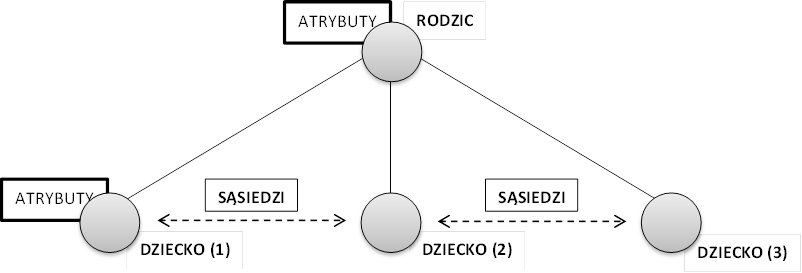

## HTML - DRZEWA

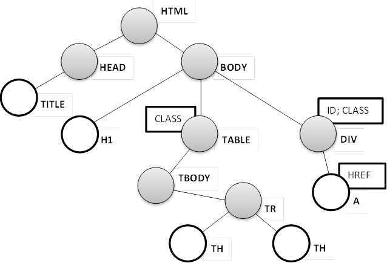

## Pliki binarne

```r
tmp <- tempfile()
url <- 'https://worksmarter.pl/media/posts/job-automation-r-1/email.png'
downloader::download(url, dest = tmp, mode = "wb")
```

## Pakiet rvest

Ekstrakcja danych

- html_nodes / html_node
- html_attrs / html_attr
- html_name (wcześniej html_tag)
- html_text
- html_table

Nawigacja po stronie

- follow / back / jump_to
- html_form / set_values / submit_form